# 马赛克图

庄亮亮

2020/11/10

记得安装prettydoc包，html模板在该包渲染而成。

## 1.前言

**马赛克图**（mosaic plot），显示分类数据中一对变量之间的关系，原理类似双向的100%堆叠式条形图，但其中所有条形在数值/标尺轴上具有相等长度，并会被划分成段。可以通过这两个变量来检测类别与其子类别之间的关系。

### 主要优点

马赛克图能按行或按列展示多个类别的比较关系。

### 主要缺点

难以阅读，特别是当含有大量分段的时候。此外，我们也很难准确地对每个分段进行比较，因为它们并非沿着共同基线排列在一起。

### 适用

马赛克图比较适合提供数据概览。

### 注意

**非坐标轴非均匀的马赛克图**也是统计学领域标准的马赛克图，一个非均匀的马赛克图包含以下构成元素：①非均匀的分类坐标轴；②面积、颜色均有含义的矩形块；③图例。对于非均匀的马赛克图，关注的数据维度非常多，一般的用户很难直观理解，在多数情况下可以被拆解成多个不同的图表，以下我们会对其进行绘制。

## 2.数据介绍

数据构建代码来源《R数据可视化之美》，任意拟定一个数据框。并用melt()函数将数据转化成以下结果：

```r
library(ggplot2)
library(RColorBrewer)
library(reshape2)  #提供melt()函数
library(plyr)      #提供ddply()函数,join()函数

df <- data.frame(segment = c("A", "B", "C","D"),Alpha = c(2400  ,1200,  600 ,250),
         Beta = c(1000  ,900,   600,    250),
         Gamma = c(400, 600 ,400,   250),
         Delta = c(200, 300 ,400,   250))

melt_df<-melt(df,id="segment")
str(melt_df)
```

```
## 'data.frame':    16 obs. of  3 variables:
##  $ segment : chr  "A" "B" "C" "D" ...
##  $ variable: Factor w/ 4 levels "Alpha","Beta",..: 1 1 1 1 2 2 2 2 3 3 ...
##  $ value   : num  2400 1200 600 250 1000 900 600 250 400 600 ...
```

计算出每行的最大，最小值，并计算每行各数的百分比。ddply()对data.frame分组计算，并利用join()函数进行两个表格连接。

```r
segpct<-rowSums(df[,2:ncol(df)])
for (i in 1:nrow(df)){
  for (j in 2:ncol(df)){
    df[i,j]<-df[i,j]/segpct[i]*100  #将数字转换成百分比
  }
}

segpct<-segpct/sum(segpct)*100
df$xmax <- cumsum(segpct)
df$xmin <- (df$xmax - segpct)

dfm <- melt(df, id = c("segment", "xmin", "xmax"),value.name="percentage")
colnames(dfm)[ncol(dfm)]<-"percentage"

#ddply()函数使用自定义统计函数，对data.frame分组计算
dfm1 <- ddply(dfm, .(segment), transform, ymax = cumsum(percentage))
dfm1 <- ddply(dfm1, .(segment), transform,ymin = ymax - percentage)
dfm1$xtext <- with(dfm1, xmin + (xmax - xmin)/2)
dfm1$ytext <- with(dfm1, ymin + (ymax - ymin)/2)

#join()函数，连接两个表格data.frame
dfm2<-join(melt_df, dfm1, by = c("segment", "variable"), type = "left", match = "all")
str(dfm2)
```

```
## 'data.frame':    16 obs. of  10 variables:
##  $ segment   : chr  "A" "B" "C" "D" ...
##  $ variable  : Factor w/ 4 levels "Alpha","Beta",..: 1 1 1 1 2 2 2 2 3 3 ...
##  $ value     : num  2400 1200 600 250 1000 900 600 250 400 600 ...
##  $ xmin      : num  0 40 70 90 0 40 70 90 0 40 ...
##  $ xmax      : num  40 70 90 100 40 70 90 100 40 70 ...
##  $ percentage: num  60 40 30 25 25 30 30 25 10 20 ...
##  $ ymax      : num  60 40 30 25 85 70 60 50 95 90 ...
##  $ ymin      : num  0 0 0 0 60 40 30 25 85 70 ...
##  $ xtext     : num  20 55 80 95 20 55 80 95 20 55 ...
##  $ ytext     : num  30 20 15 12.5 72.5 55 45 37.5 90 80 ...
```

## 2.方法

### 2.1 ggplot2包的geom_rect()函数

这个方法比较复杂，图层一层一层叠加得到的，不过灵活性比较强，可根据自己喜好进行修改。

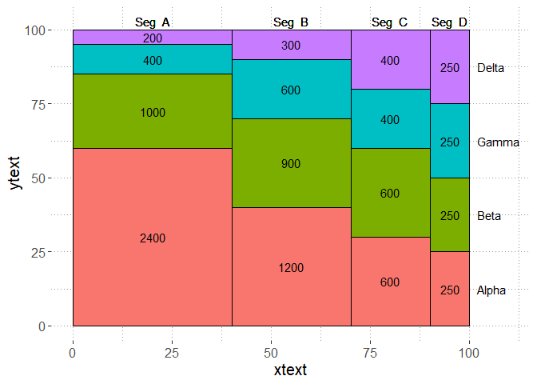

```r
ggplot()+
  geom_rect(aes(ymin = ymin, ymax = ymax, xmin = xmin, xmax = xmax, fill = variable),dfm2,colour = "black") +
  geom_text(aes(x = xtext, y = ytext,  label = value),dfm2 ,size = 4)+
  geom_text(aes(x = xtext, y = 103, label = paste("Seg ", segment)),dfm2 ,size = 4)+
  geom_text(aes(x = 102, y = seq(12.5,100,25), label = c("Alpha","Beta","Gamma","Delta")), size = 4,hjust = 0)+
  scale_x_continuous(breaks=seq(0,100,25),limits=c(0,110))+
  theme(panel.background=element_rect(fill="white",colour=NA),
        panel.grid.major = element_line(colour = "grey60",size=.25,linetype ="dotted" ),
        panel.grid.minor = element_line(colour = "grey60",size=.25,linetype ="dotted" ),
        text=element_text(size=15),
        legend.position="none")
```

**图形解释：**这个马赛克图，从A这列纵向看可以看出各个指标(Delta,Gamma等)的占比情况，从横向来看，不同变量（A,B等）的宽度代表该变量占所有数据的占比情况，越宽说明该变量数据总和越大。

### 2.2 vcd包的mosaic()函数

```r
library(vcd)
```

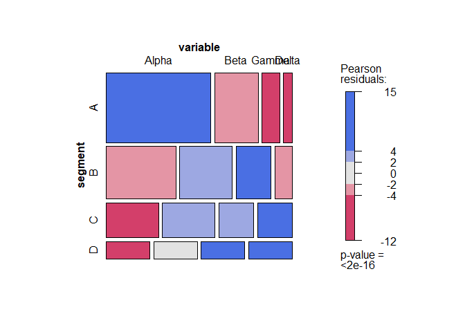

```r
table<-xtabs(value ~variable+segment, melt_df)
mosaic( ~segment+variable,table,shade=TRUE,legend=TRUE,color=TRUE)
```

### 2.3 graphics包的mosaicplot()函数

该方法和上面类似，掉包就行，数据类型与上面相同。

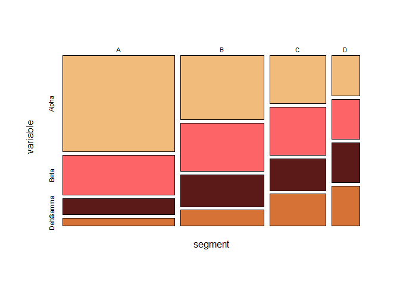

```r
library(graphics)
library(wesanderson) #颜色提取
mosaicplot( ~segment+variable,table, color = wes_palette("GrandBudapest1"),main = '')
```

## 参考

1. 《R数据可视化之美》
2. https://blog.csdn.net/tobeyourlover/article/details/52704333?%3E

[figure not shown]

欢迎**关注**我的**公众号**，**点赞，在看，收藏~~~**